# 08.Unit Standards

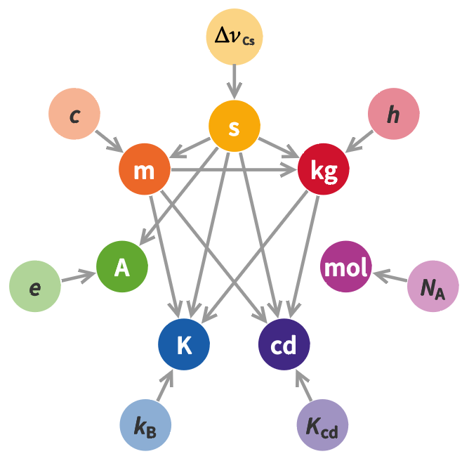

## Primary Standards

Primary unit standards are precise definitions of physical variables.

Some examples of standards in everyday use are:

- [United States Customary Units (USCS or USC)](https://en.wikipedia.org/wiki/United_States_customary_units)
- [Imperial Units](https://en.wikipedia.org/wiki/Imperial_units)
- [English Units](https://en.wikipedia.org/wiki/English_units)
- [English Engineering Units](https://en.wikipedia.org/wiki/English_Engineering_units)
- [International System of Units (SI)](https://en.wikipedia.org/wiki/International_System_of_Units)

The seven different SI primary standards are:

- Time - second ($s$)
- Mass - kilogram ($kg$)
- Amount of substance - mole ($mol$)
- Luminous intensity - candela ($cd$)
- Temperature - Kelvin ($K$)
- Current - ampere ($A$)
- Length - meter ($m$)

As of May 20th, 2019, the primary standards for the SI system were updated.

The following changes were made.

- 4 of the 7 were redefined; $kg$, $A$, $K$, and $mol$
- 2 were corrected; $m$, and $cd$

## Time

The second is defined as $$ 1s \equiv \frac{9,192,631,770}{\Delta \nu_{Cs}} $$

where $ \Delta \nu_{Cs} $ is the frequency of the radiation corresponding to the transition between two hyperfine levels of the ground state of cesium-133 atom.

Figure 1: The FOCS 1

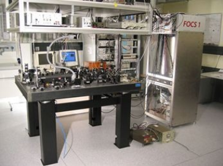

The FOCS 1 started in 2004 and has an uncertainty of $1s$ in 30 million years ($9.46728\times10^{14}s$).

## Mass

The old definition is

1. The kilogram is the mass of a platinum-iridium cylinder called "International Prototype Kilogram" (IPK), sometimes called Le Grand K, kept at the International Bureau of Weights and Measurements in France.

Figure 2: The International Prototype Kilogram

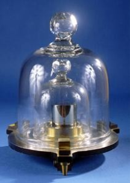

Figure 3: IPK vs Sister Copies

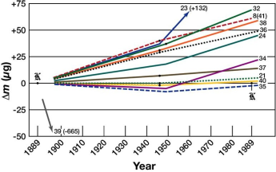

The new definition is

$$ 1kg \equiv \frac{\left( 299,792,458 \right)^2}{\left( 6.62607015 \times 10^{-34} \right)\left( 9,192,631,770 \right)} \frac{h \Delta \nu_{Cs}}{c^2} $$

where

- $h$ is the [Planck constant](https://en.wikipedia.org/wiki/Planck_constant)
- $ \Delta \nu_{Cs} $ is as defined previously
- $ c $ is the speed of light in a vacuum

## Amount Of Substance

The old definition is

1. The mole is the amount of substance of a system containing as many elementary entities as atoms in $ 0.012 kg$ of carbon-12.

Figure 4: Carbon-12 Isotope

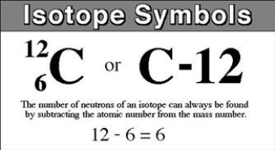

The new definition is

$$ 1 mol \equiv \frac{6.02214076 \times 10^{23}}{N_A} $$

where $ N_A$ is the [Avogadro constant](https://en.wikipedia.org/wiki/Avogadro_constant).

Figure 5: Amedeo Avogadro

[figure not shown]

## Luminous Intensity

The old definition is

1. The luminous intensity, in a given direction, of a source that emits monochromatic radiation of frequency $ 540 \times 10^2 Hz$ and of which the radiant intensity in that direction is $ \frac{1}{683} \frac{W}{sr} $.

Figure 6: Steradian

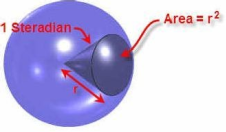

The new definition is

$$ 1 cd \equiv \frac{K_{cd} h c \Delta \nu_{Cs}}{\left( 683 \right)\left( 6.62607015 \times 10^{-34} \right)\left( 299,792,458 \right)\left( 9,192,631,770 \right)} $$

where $K_{cd}$ is the [luminous efficacy](https://en.wikipedia.org/wiki/Luminous_efficacy) of monochromatic radiation of frequency $540 \times 10^2 Hz$ and all the other constants are as previously described.

## Temperature

The old definition is

1. The Kelvin is $ 1 / 273.16 $ of the triple point of water.

Figure 7: Water Phase Diagram with Triple Point Location

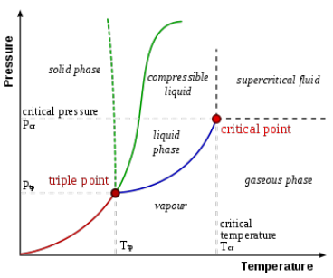

The new definition is

$$ 1 K \equiv \frac{1.380649 \times 10^{-23}}{\left( 6.62607015 \times 10^{-34} \right)\left( 9,192,631,770 \right)} \frac{h \Delta \nu_{Cs}}{k} $$

where $k$ is the [Boltzman constant](https://en.wikipedia.org/wiki/Boltzmann_constant) and all other constants are as previously defined.

## Current

The old definition is

1. The ampere is the constant current that occurs in two straight parallel conductors of infinite length, and negligible circular sections placed $1$ meter apart in a vacuum producing a force equal to $2 \times 10^{-7} N/m$.

Figure 8: Old Ampere Definition

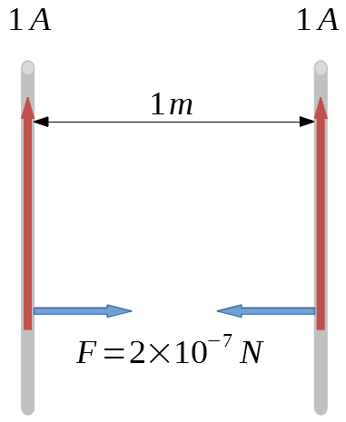

The red arrows show the flow of electricity through each conductor

The blue arrows show the force of attraction between the two conductors

The new definition is

$$ 1 A \equiv \frac{e \Delta \nu_{Cs}}{\left( 1.602176634 \times 10^{-19} \right)\left( 9,192,631,770 \right)} $$

where $e$ is the [elementary charge](https://en.wikipedia.org/wiki/Elementary_charge) and $\Delta \nu_{Cs}$ is as previously defined.

## Length

At one time it was

1. One ten-millionth of the distance between the north pole and the equator at Paris's longitude.

Figure 9: Platinum and iridium prototype meter stick

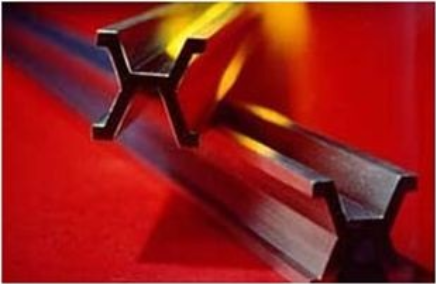

The old definition is

1. The meter is the length of the path traveled by light in a vacuum during a duration of $1/299,792,458$ of a second.

The new definition is

$$ 1 m \equiv \frac{9,192,631,770}{299,792,458} \frac{c}{\Delta \nu_{Cs}} $$

## Terminology of Standards

A fixed standard is one that cannot be reproduced in a lab

A reproducible standard is one that may be reproduced in a properly equipped lab

Secondary standards are standards that have been compared to a primary standard at some point in time

Figure 10: Standard Mass Set

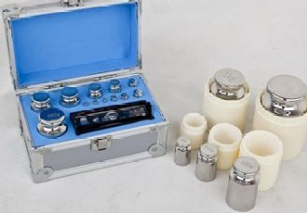

Figure 11: Gage Blocks

[figure not shown]